# DATA606 - Multiple Regression

November 11, 2020

## Meetup Presentations

- 8.21 - Bharani Nittala
- Alexis Mekueko
- 8.23 - [Irene Jacob](https://rpubs.com/Irene_J/684300) [Video](https://youtu.be/K8l50K5_idQ)

## Weight of Books

```r
allbacks <- read.csv('../course_data/allbacks.csv')
head(allbacks)
```

```
##   X volume area weight cover
## 1 1    885  382    800    hb
## 2 2   1016  468    950    hb
## 3 3   1125  387   1050    hb
## 4 4    239  371    350    hb
## 5 5    701  371    750    hb
## 6 6    641  367    600    hb
```

From: Maindonald, J.H. & Braun, W.J. (2007). *Data Analysis and Graphics Using R, 2nd ed.*

## Weights of Books (cont)

```r
lm.out <- lm(weight ~ volume, data=allbacks)
```

\[ \hat{weight} = 108 + 0.71 volume \] \[ R^2 = 80\% \]

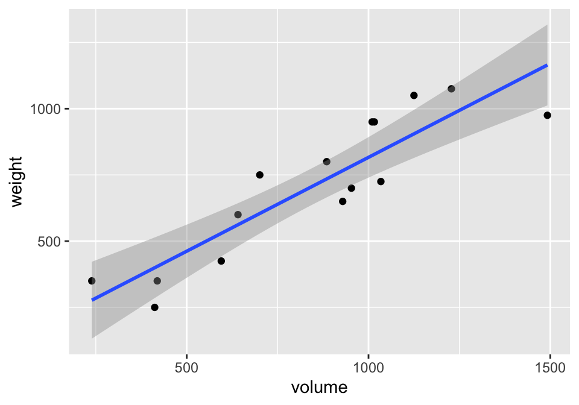

## Modeling weights of books using volume

```r
summary(lm.out)
```

```
##
## Call:
## lm(formula = weight ~ volume, data = allbacks)
##
## Residuals:
##     Min      1Q  Median      3Q     Max
## -189.97 -109.86   38.08  109.73  145.57
##
## Coefficients:
##              Estimate Std. Error t value Pr(>|t|)
## (Intercept) 107.67931   88.37758   1.218    0.245
## volume        0.70864    0.09746   7.271 6.26e-06 ***
## ---
## Signif. codes:  0 '***' 0.001 '**' 0.01 '*' 0.05 '.' 0.1 ' ' 1
##
## Residual standard error: 123.9 on 13 degrees of freedom
## Multiple R-squared:  0.8026, Adjusted R-squared:  0.7875
## F-statistic: 52.87 on 1 and 13 DF,  p-value: 6.262e-06
```

## Weights of hardcover and paperback books

- Can you identify a trend in the relationship between volume and weight of hardcover and paperback books?

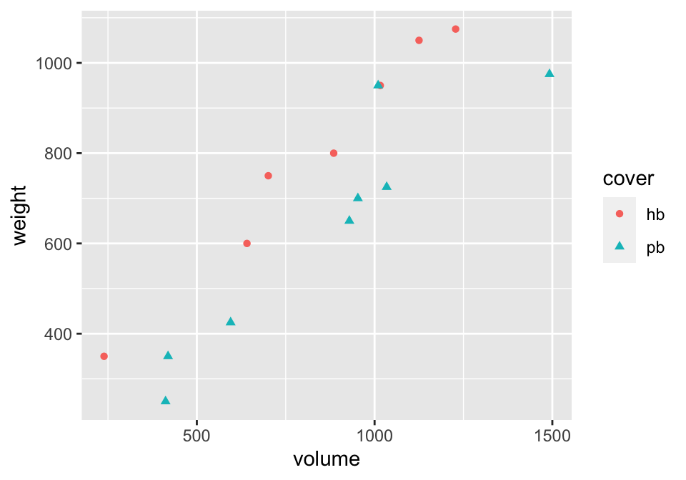

- Paperbacks generally weigh less than hardcover books after controlling for book’s volume.

## Modeling weights of books using volume and cover type

```r
lm.out2 <- lm(weight ~ volume + cover, data=allbacks)
summary(lm.out2)
```

```
##
## Call:
## lm(formula = weight ~ volume + cover, data = allbacks)
##
## Residuals:
##     Min      1Q  Median      3Q     Max
## -110.10  -32.32  -16.10   28.93  210.95
##
## Coefficients:
##               Estimate Std. Error t value Pr(>|t|)
## (Intercept)  197.96284   59.19274   3.344 0.005841 **
## volume         0.71795    0.06153  11.669  6.6e-08 ***
## coverpb     -184.04727   40.49420  -4.545 0.000672 ***
## ---
## Signif. codes:  0 '***' 0.001 '**' 0.01 '*' 0.05 '.' 0.1 ' ' 1
##
## Residual standard error: 78.2 on 12 degrees of freedom
## Multiple R-squared:  0.9275, Adjusted R-squared:  0.9154
## F-statistic: 76.73 on 2 and 12 DF,  p-value: 1.455e-07
```

## Linear Model

\[ \hat{weight} = 198 + 0.72 volume - 184 coverpb \]

1. For **hardcover** books: plug in *0* for cover.  
   \[ \hat{weight} = 197.96 + 0.72 volume - 184.05 \times 0 = 197.96 + 0.72 volume \]
2. For **paperback** books: put in 1 for cover. \[ \hat{weight} = 197.96 + 0.72 volume - 184.05 \times 1 \]

## Visualizing the linear model

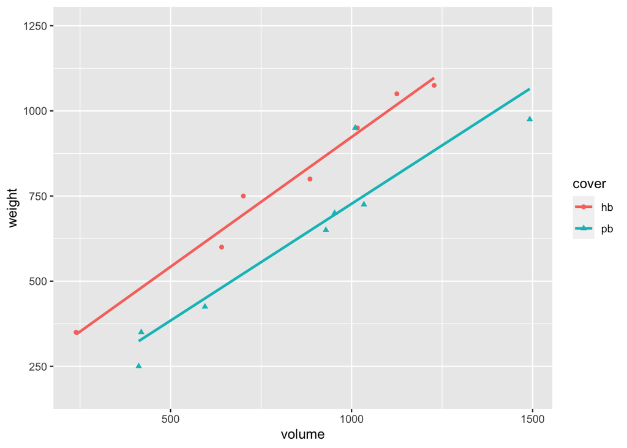

## Interpretation of the regression coefficients

|  | Estimate | Std. Error | t value | Pr(>\|t\|) |
| --- | --- | --- | --- | --- |
| (Intercept) | 197.9628 | 59.1927 | 3.34 | 0.0058 |
| volume | 0.7180 | 0.0615 | 11.67 | 0.0000 |
| coverpb | -184.0473 | 40.4942 | -4.55 | 0.0007 |

- **Slope of volume**: All else held constant, books that are 1 more cubic centimeter in volume tend to weigh about 0.72 grams more.
- **Slope of cover**: All else held constant, the model predicts that paperback books weigh 184 grams lower than hardcover books.
- **Intercept**: Hardcover books with no volume are expected on average to weigh 198 grams.
  - Obviously, the intercept does not make sense in context. It only serves to adjust the height of the line.

## Modeling Poverty

```r
poverty <- read.table("../course_data/poverty.txt", h = T, sep = "\t")
names(poverty) <- c("state", "metro_res", "white", "hs_grad", "poverty", "female_house")
poverty <- poverty[,c(1,5,2,3,4,6)]
head(poverty)
```

```
##        state poverty metro_res white hs_grad female_house
## 1    Alabama    14.6      55.4  71.3    79.9         14.2
## 2     Alaska     8.3      65.6  70.8    90.6         10.8
## 3    Arizona    13.3      88.2  87.7    83.8         11.1
## 4   Arkansas    18.0      52.5  81.0    80.9         12.1
## 5 California    12.8      94.4  77.5    81.1         12.6
## 6   Colorado     9.4      84.5  90.2    88.7          9.6
```

From: Gelman, H. (2007). *Data Analysis using Regression and Multilevel/Hierarchial Models.* Cambridge University Press.

## Modeling Poverty

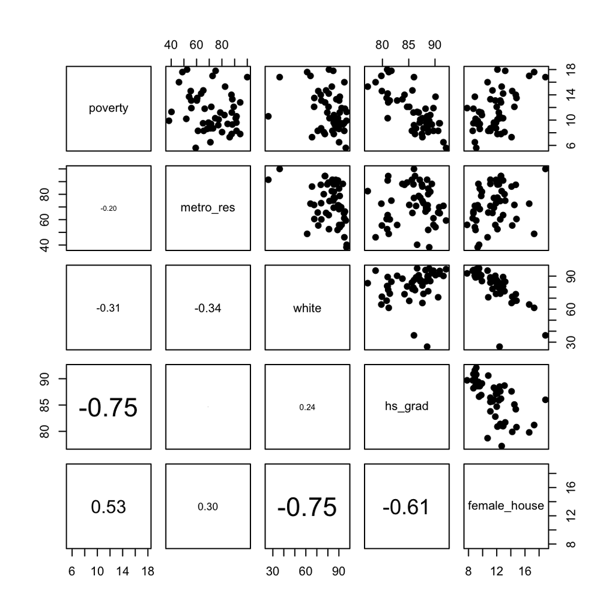

## Predicting Poverty using Percent Female Householder

```r
lm.poverty <- lm(poverty ~ female_house, data=poverty)
summary(lm.poverty)
```

```
##
## Call:
## lm(formula = poverty ~ female_house, data = poverty)
##
## Residuals:
##     Min      1Q  Median      3Q     Max
## -5.7537 -1.8252 -0.0375  1.5565  6.3285
##
## Coefficients:
##              Estimate Std. Error t value Pr(>|t|)
## (Intercept)    3.3094     1.8970   1.745   0.0873 .
## female_house   0.6911     0.1599   4.322 7.53e-05 ***
## ---
## Signif. codes:  0 '***' 0.001 '**' 0.01 '*' 0.05 '.' 0.1 ' ' 1
##
## Residual standard error: 2.664 on 49 degrees of freedom
## Multiple R-squared:  0.276,  Adjusted R-squared:  0.2613
## F-statistic: 18.68 on 1 and 49 DF,  p-value: 7.534e-05
```

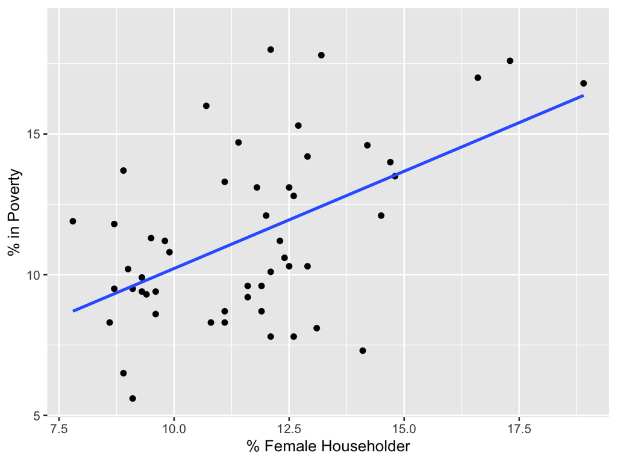

## Another look at \(R^2\)

\(R^2\) can be calculated in three ways:

1. square the correlation coefficient of x and y (how we have been calculating it)
2. square the correlation coefficient of y and \(\hat{y}\)
3. based on definition:  
   \[ R^2 = \frac{explained \quad variability \quad in \quad y}{total \quad variability \quad in \quad y} \]

Using ANOVA we can calculate the explained variability and total variability in y.

## Sum of Squares

```r
anova.poverty <- anova(lm.poverty)
print(xtable(anova.poverty, digits = 2), type='html')
```

|  | Df | Sum Sq | Mean Sq | F value | Pr(>F) |
| --- | --- | --- | --- | --- | --- |
| female_house | 1.00 | 132.57 | 132.57 | 18.68 | 0.00 |
| Residuals | 49.00 | 347.68 | 7.10 |  |  |

Sum of squares of *y*: \({ SS }_{ Total }=\sum { { \left( y-\bar { y } \right) }^{ 2 } } =480.25\) → **total variability**

Sum of squares of residuals: \({ SS }_{ Error }=\sum { { e }_{ i }^{ 2 } } =347.68\) → **unexplained variability**

Sum of squares of *x*: \({ SS }_{ Model }={ SS }_{ Total }-{ SS }_{ Error } = 132.57\) → **explained variability**

\[ R^2 = \frac{explained \quad variability \quad in \quad y}{total \quad variability \quad in \quad y} = \frac{132.57}{480.25} = 0.28 \]

## Why bother?

- For single-predictor linear regression, having three ways to calculate the same value may seem like overkill.
- However, in multiple linear regression, we can’t calculate \(R^2\) as the square of the correlation between *x* and *y* because we have multiple *x*s.
- And next we’ll learn another measure of explained variability, *adjusted \(R^2\)*, that requires the use of the third approach, ratio of explained and unexplained variability.

## Predicting poverty using % female household and % white

```r
lm.poverty2 <- lm(poverty ~ female_house + white, data=poverty)
print(xtable(lm.poverty2), type='html')
```

|  | Estimate | Std. Error | t value | Pr(>\|t\|) |
| --- | --- | --- | --- | --- |
| (Intercept) | -2.5789 | 5.7849 | -0.45 | 0.6577 |
| female_house | 0.8869 | 0.2419 | 3.67 | 0.0006 |
| white | 0.0442 | 0.0410 | 1.08 | 0.2868 |

```r
anova.poverty2 <- anova(lm.poverty2)
print(xtable(anova.poverty2, digits = 2), type='html')
```

|  | Df | Sum Sq | Mean Sq | F value | Pr(>F) |
| --- | --- | --- | --- | --- | --- |
| female_house | 1.00 | 132.57 | 132.57 | 18.74 | 0.00 |
| white | 1.00 | 8.21 | 8.21 | 1.16 | 0.29 |
| Residuals | 48.00 | 339.47 | 7.07 |  |  |

\[ R^2 = \frac{explained \quad variability \quad in \quad y}{total \quad variability \quad in \quad y} = \frac{132.57 + 8.21}{480.25} = 0.29 \]

Does adding the variable `white` to the model add valuable information that wasn’t provided by `female_house`?

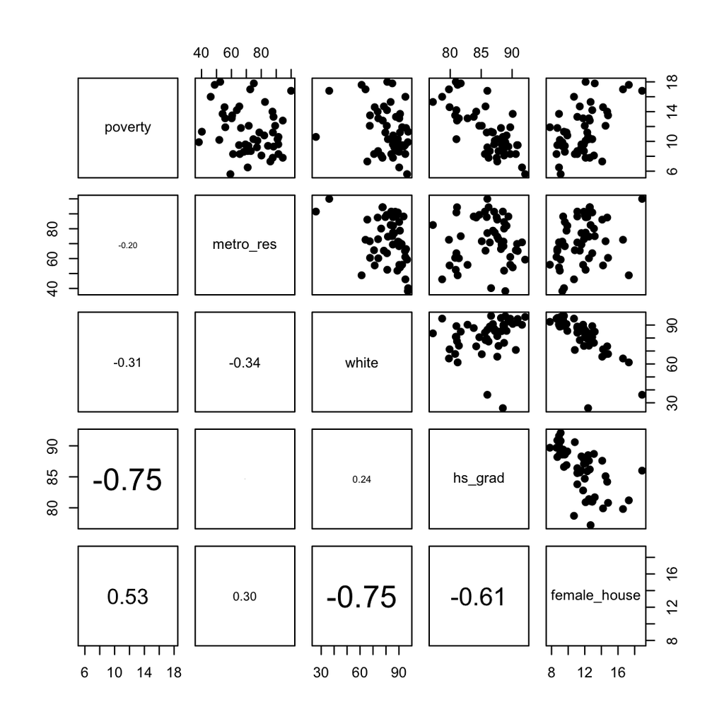

## Collinearity between explanatory variables

poverty vs % female head of household

|  | Estimate | Std. Error | t value | Pr(>\|t\|) |
| --- | --- | --- | --- | --- |
| (Intercept) | 3.3094 | 1.8970 | 1.74 | 0.0873 |
| female_house | 0.6911 | 0.1599 | 4.32 | 0.0001 |

|  | Estimate | Std. Error | t value | Pr(>\|t\|) |
| --- | --- | --- | --- | --- |
| (Intercept) | -2.5789 | 5.7849 | -0.45 | 0.6577 |
| female_house | 0.8869 | 0.2419 | 3.67 | 0.0006 |
| white | 0.0442 | 0.0410 | 1.08 | 0.2868 |

Note the difference in the estimate for `female_house`.

## Collinearity between explanatory variables

- Two predictor variables are said to be collinear when they are correlated, and this collinearity complicates model estimation.  
  Remember: Predictors are also called explanatory or independent variables. Ideally, they would be independent of each other.
- We don’t like adding predictors that are associated with each other to the model, because often times the addition of such variable brings nothing to the table. Instead, we prefer the simplest best model, i.e. *parsimonious* model.
- While it’s impossible to avoid collinearity from arising in observational data, experiments are usually designed to prevent correlation among predictors

## \(R^2\) vs. adjusted \(R^2\)

| Model | \(R^2\) | Adjusted \(R^2\) |
| --- | --- | --- |
| Model 1 (Single-predictor) | 0.28 | 0.26 |
| Model 2 (Multiple) | 0.29 | 0.26 |

- When any variable is added to the model \(R^2\) increases.
- But if the added variable doesn’t really provide any new information, or is completely unrelated, adjusted \(R^2\) does not increase.

## Adjusted \(R^2\)

\[ { R }_{ adj }^{ 2 }={ 1-\left( \frac { { SS }_{ error } }{ { SS }_{ total } } \times \frac { n-1 }{ n-p-1 } \right) } \]

where *n* is the number of cases and *p* is the number of predictors (explanatory variables) in the model.

- Because *p* is never negative, \({ R }_{ adj }^{ 2 }\) will always be smaller than \(R^2\).
- \({ R }_{ adj }^{ 2 }\) applies a penalty for the number of predictors included in the model.
- Therefore, we choose models with higher \({ R }_{ adj }^{ 2 }\) over others.